# 9-30-16 Antag Screen Results

This experiment was performed to show that the new protocol from the E cell optimization was consistent with previous results from the antagonist screen performed with the Hana3A cells. Due to human error, many of the TMA alone wells did not work (see lab notebook for details), so the results from this experiment are skewed. I will show some examples of how the results from this experiment do not make sense.

This experiment also contained a sub-experiment. Previously, we were worried that due to runover contaimination between wells, that the cells were receiving higher than the EC80 of TMA (500uM). To test this, I ran a dose-response curve in the middle of the plate (for both TMA and forskolin). I expected to see that the TMA by itself responded higher than the respective concentration calculated from my dose response experiment.

# Dose Response Experiment:

```
## EC50 and 80 for TAAR5:
```

```
##
## Estimated effective doses
## (Delta method-based confidence interval(s))
##
##        Estimate Std. Error      Lower Upper
## 1:50 1.7735e-05 5.1375e-06 7.3667e-06 0e+00
## 1:80 7.0938e-05 2.0550e-05 2.9467e-05 1e-04
```

```
## EC50 and 80 for Rho:
```

```
##
## Estimated effective doses
## (Delta method-based confidence interval(s))
##
##        Estimate Std. Error      Lower Upper
## 1:50 1.7306e-06 2.0524e-07 1.3164e-06     0
## 1:80 6.9225e-06 8.2095e-07 5.2658e-06     0
```

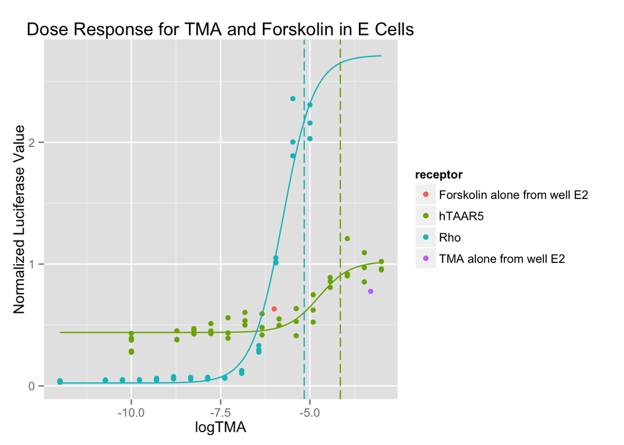

Important Observations:  
1. Even though the dose responses of forskolin and TMA are not balanced, TMA and forskolin by themselves have an equivalent response (of course, this is approximate because we have only one data point so we can’t see the variation). It is important that the control (forskolin) is at a concentration where the cell response is equivalent to the cell response to the agonist at EC80.

2. Both TMA and forskolin alone are lower than the response curve, which is the opposite of what we expected. For TMA, it appears that the TMA alone could be similar to the point in the curve given the variation. For forskolin, this is likely becuase the fit of the curve is not very good.
3. 500uM TMA (the EC80 calculated from DRs on the H3A cells), is higher than the EC80 for E cells (green dashed line). But also, the response to this TMA alone (which we can consider with concentration x for this experiment) has a lower response than the EC80 for these E cells. EC80 need to be calculated for previous runs with E cells. And we need to figure out why the response to TMA alone is so much lower than expected.

How does this dose Response experiment look for the hana3A cells?

```r
#calculate the EC50 and 80
cat("EC50 and 80 for TAAR5:")
```

```
## EC50 and 80 for TAAR5:
```

```r
EC.TAAR <- ED(modelTAAR5, c(50,80), interval = "delta")[2,1]
```

```
##
## Estimated effective doses
## (Delta method-based confidence interval(s))
##
##        Estimate Std. Error      Lower Upper
## 1:50 4.2819e-05 1.1434e-05 1.9745e-05 1e-04
## 1:80 1.7128e-04 4.5734e-05 7.8981e-05 3e-04
```

```r
cat("EC50 and 80 for Rho:")
```

```
## EC50 and 80 for Rho:
```

```r
EC.Rho <- ED(modelRho, c(50,80), interval = "delta")[2,1]
```

```
##
## Estimated effective doses
## (Delta method-based confidence interval(s))
##
##        Estimate Std. Error      Lower Upper
## 1:50 1.4562e-07 1.8666e-08 1.0795e-07     0
## 1:80 5.8247e-07 7.4666e-08 4.3179e-07     0
```

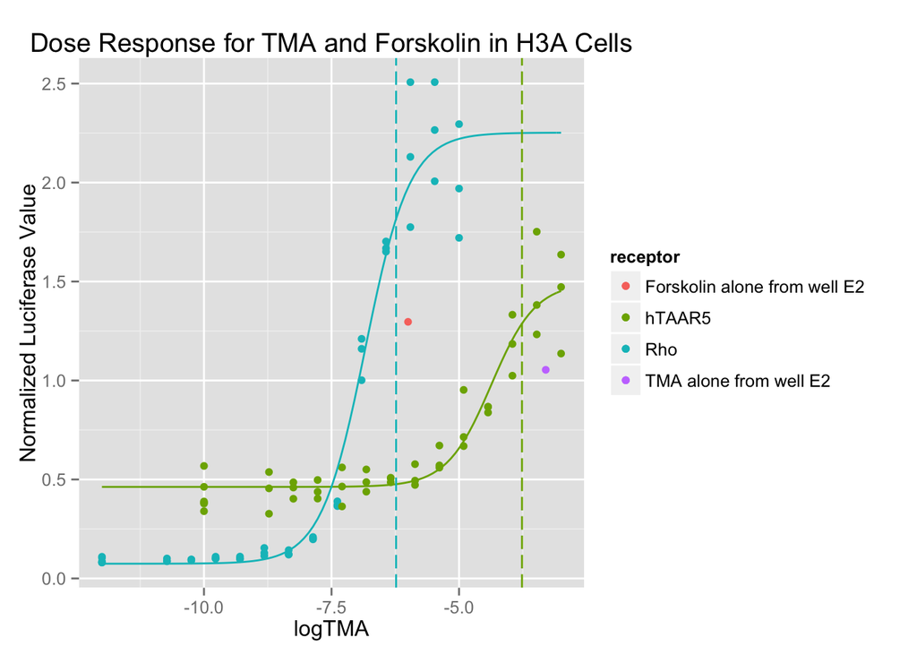

Observations:  
1. The variance in both dose response curves is very large, especially at the higher concentrations. This could cause a problem in interpreting the antagonist results.

2. Again the TMA and forskolin alone are both similar to one another in response, and also both below the expect response for their concentrations.
3. 500uM is closer to the EC80 value of this experiment in these H3A cells than it was in the E cells, but it still does not quite match up. I’m not sure why this happens, but this questionable finding is good evidence that this experiment should be repeated.

# Antagonist Experiment:

It is unclear if we should read much out of the results of this part of the experiment given that all comparisons of antagonist action are compared to only one response value of TMA alone. However, we can still compare the results between the E Cells and the H3A cells to see if there is any consistancy whatsoever.

## Rankings in this screen of the top hits from previous screen

(486 = 1221 = PEB)  
### E Cells

```
## TAAR5:
```

```
##     plateLocation antagInStockKey      norm    PerAg   PerInhib rank
## 683           K19             486 0.8529972 109.8547  -9.854716  102
## 684           L19             678 0.9447501 121.6713 -21.671266  163
## 469            E6             827 0.9594649 123.5663 -23.566330  173
## 394            J1            1221 1.0655376 137.2271 -37.227084  220
## 701           M20             527 1.1259843 145.0118 -45.011816  248
## 441            I4             821 1.2395031 159.6315 -59.631537  283
```

```
## Rho Control:
```

```
##     plateLocation antagInStockKey      norm     PerAg   PerInhib rank
## 300           L19             678 0.4014855  63.55001  36.449987    1
## 57             I4             821 0.6727415 106.48638  -6.486381  135
## 85             E6             827 0.7082984 112.11458 -12.114580  165
## 299           K19             486 0.8239482 130.42047 -30.420467  216
## 317           M20             527 0.8916823 141.14191 -41.141910  242
## 10             J1            1221 1.2118515 191.82060 -91.820601  303
```

```
## TAAR5:
```

```
##     plateLocation antagInStockKey      norm     PerAg   PerInhib rank
## 469            E6             827 0.9689441  91.93134   8.068661   39
## 394            J1            1221 1.0294821  97.67505   2.324948   58
## 441            I4             821 1.0847162 102.91554  -2.915544   80
## 684           L19             678 1.2651072 120.03066 -20.030661  142
```

```
## Rho Control:
```

```
##     plateLocation antagInStockKey     norm     PerAg   PerInhib rank
## 85             E6             827 1.244675  96.01608   3.983918   21
## 57             I4             821 1.689606 130.33873 -30.338729  188
## 299           K19             486 1.691561 130.48955 -30.489551  190
## 10             J1            1221 1.777053 137.08458 -37.084578  218
## 300           L19             678 2.046863 157.89811 -57.898107  287
## 317           M20             527 2.074733 160.04803 -60.048033  293
```

These rankings of the old top hits don’t look similar at all between E cells and H3A cells. This is probably also due to the fact that we are only comparing them to one point of TMA alone.

# Conclusions

This experiment needs to be re-run. It would be helpful to run the dose response in the middle of the plate again to get better comparisons of the EC80 value. Beyond the lack of positive controls, another thing that could have contributed to the data is that I did not make new odor dilution plates, but instead used the ones that I had made in march for the last time I tried to repeat the TAAR5 antagonist screen. It is possible that since the dilution plates were sitting in the fridge for so long this may have affected some of the odors. This is probably a minor variable compared to the fact that so few of the postive controls were successful.